# SASMarkdown

# Try a online dataset

```
filename myurl url "https://www.utsc.utoronto.ca/~butler/c32/soap.txt";

proc import
  datafile=myurl
  out=soap
  dbms=dlm
  replace;
  getnames=yes;
  delimiter=" ";
```

After that, proceed as you would in the SAS IDE (or on SAS Studio online), *without* `collectcode` on the top of the code chunk:

```
proc means;
  var scrap speed;
```

Variable

N

Mean

Std Dev

Minimum

Maximum

| scrap |
| --- |
| speed |

| 27 |
| --- |
| 27 |

| 315.4814815 |
| --- |
| 210.1851852 |

| 82.9895129 |
| --- |
| 63.4198689 |

| 140.0000000 |
| --- |
| 100.0000000 |

| 470.0000000 |
| --- |
| 320.0000000 |

This works because the “collected” chunk with the `proc import` in it is added to the top of this code, so that the data set is read in again, and because it “belongs” to this chunk, the variables `scrap` and `speed` will be found. We could also run a regression in the same way:

```
proc reg;
  model scrap=speed;
```

Model: MODEL1

Dependent Variable: scrap

| Number of Observations Read | 27 |
| --- | --- |
| Number of Observations Used | 27 |

| Analysis of Variance Source | Analysis of Variance DF | Analysis of Variance Sum of Squares | Analysis of Variance Mean Square | Analysis of Variance F Value | Analysis of Variance Pr > F |
| --- | --- | --- | --- | --- | --- |
| Model | 1 | 149661 | 149661 | 127.23 | <.0001 |
| Error | 25 | 29408 | 1176.31033 |  |  |
| Corrected Total | 26 | 179069 |  |  |  |

| Root MSE | 34.29738 | R-Square | 0.8358 |
| --- | --- | --- | --- |
| Dependent Mean | 315.48148 | Adj R-Sq | 0.8292 |
| Coeff Var | 10.87144 |  |  |

| Parameter Estimates Variable | Parameter Estimates DF | Parameter Estimates Parameter Estimate | Parameter Estimates Standard Error | Parameter Estimates t Value | Parameter Estimates Pr > \|t\| |
| --- | --- | --- | --- | --- | --- |
| Intercept | 1 | 64.03568 | 23.24876 | 2.75 | 0.0108 |
| speed | 1 | 1.19631 | 0.10606 | 11.28 | <.0001 |

Model: MODEL1

Dependent Variable: scrap

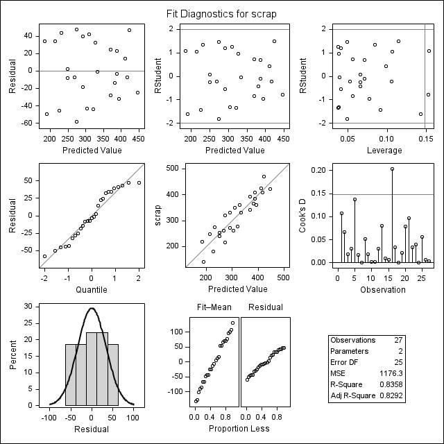

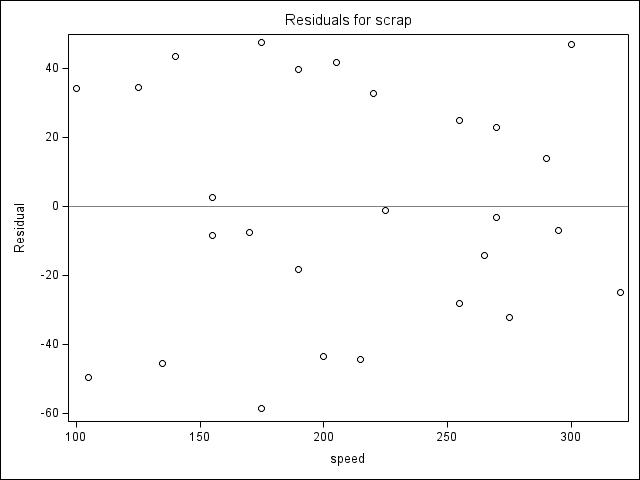

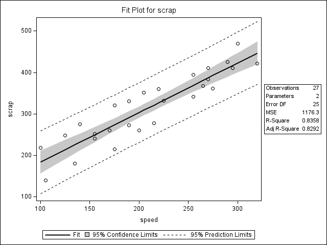

You could also have a second chunk of “collected” code. For example, you might want to run a regression, saving an output data set (say, with the residuals in it), and, later, do something with the residuals. My example below saves the leverages (along with all the original variables). The `noprint` on the first line suppresses the regression output, which we saw before and don’t want to see again:

```
proc reg noprint;
  model scrap=speed;
  output out=saved h=leverage;
```

Because I put `collectcode=T` in *this* code chunk header, our collection of code now includes (a) reading in the data and (b) running this regression, obtaining the output data set with the leverages in it. Thus, to display the leverages in order, I now only need to do this:

```
proc sort;
  by descending leverage;
proc print;
```

| Obs | case | scrap | speed | line | leverage |
| --- | --- | --- | --- | --- | --- |
| 1 | 1 | 218 | 100 | a | 0.15313 |
| 2 | 25 | 422 | 320 | b | 0.15236 |
| 3 | 16 | 140 | 105 | b | 0.14284 |
| 4 | 5 | 470 | 300 | a | 0.11418 |
| 5 | 2 | 248 | 125 | a | 0.10643 |
| 6 | 27 | 410 | 295 | b | 0.10583 |
| 7 | 14 | 425 | 290 | a | 0.09795 |
| 8 | 21 | 180 | 135 | b | 0.09109 |
| 9 | 13 | 275 | 140 | a | 0.08414 |
| 10 | 23 | 361 | 275 | b | 0.07721 |
| 11 | 9 | 410 | 270 | a | 0.07125 |
| 12 | 18 | 384 | 270 | b | 0.07125 |
| 13 | 11 | 241 | 155 | a | 0.06616 |
| 14 | 24 | 252 | 155 | b | 0.06616 |
| 15 | 15 | 367 | 265 | a | 0.06577 |
| 16 | 6 | 394 | 255 | a | 0.05624 |
| 17 | 19 | 341 | 255 | b | 0.05624 |
| 18 | 10 | 260 | 170 | a | 0.05248 |
| 19 | 8 | 321 | 175 | a | 0.04888 |
| 20 | 20 | 215 | 175 | b | 0.04888 |
| 21 | 12 | 331 | 190 | a | 0.04093 |
| 22 | 26 | 273 | 190 | b | 0.04093 |
| 23 | 7 | 332 | 225 | a | 0.03914 |
| 24 | 22 | 260 | 200 | b | 0.03803 |
| 25 | 3 | 360 | 220 | a | 0.03796 |
| 26 | 4 | 351 | 205 | a | 0.03729 |
| 27 | 17 | 277 | 215 | b | 0.03726 |

and everything will work. I sorted the leverages so that you can observe that the highest leverages go with the most extreme (highest or lowest) `speed` values.